# 1.1) Structuring the study area

Hugo Flávio

2019-07-13

## Index

1. Preparing your data
   1. **Structuring the study area**
   2. Creating a distances matrix
2. Running actel
3. What is actel doing?
   1. Errors and messages
4. Inspecting the results
5. Refining the results

## From the field to the computer

To be able to process your data, actel must understand how your study area works. To do this, actel relies on two things: the study area sections and the hydrophone arrays.

Here is a visual example of a study area with an overlay of the respective arrays and sections:

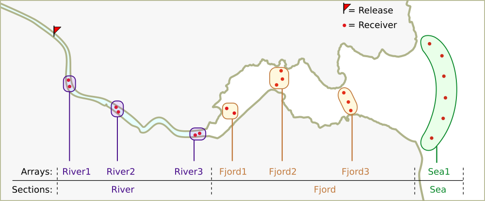

### Sections

The sections divide your study area in big blocks, for which you are interested in knowing the time of arrival/departure and wether or not the fish disappeared in that section. For example, if your fish must cross a river and a fjord before reaching the end of the study area, then your sections will likely be “River” and “Fjord”. In the example above, there are three sections: River, Fjord and Sea.

By the end of the analysis, you will know at what time the fish entered and left each section, the time it spent inside that section, and how long it took for the fish to reach the next section.

The sections are typed into the `actel()` function, and should be ordered in the order that you expect your fish will cross them. For example, if you expect your fish to move from the river to a fjord and ultimately to the sea (and you have hydrophone arrays in all these sections), then `sections = c("River","Fjord","Sea")`. On the other hand, if you expect your fish to migrate upstream, then `sections = c("Sea","Fjord","River")`.

### Arrays

The hydrophone arrays are tightly linked to the study sections. An array called “River1” is expected to belong to section “River”, an array called “Fjord3” is expected to belong to section “Fjord”, and so forth. Array names **must** be an exact copy of the section they belong to, plus the number of the array. The order by which the fish are expected to pass these arrays is determined by the array number (i.e. River1 comes before River2). Therefore, it is **very important** that you number your arrays correctly.

#### Avoid overlapping arrays

When a fish moves from one array to another, a new movement event is created (you will learn more about movement events later on). This means that, if you have two hydrophones close to each other, but listed in two different arrays, you can end up with many ‘false’ movement events (i.e. the fish is just standing still within range of both arrays). Here is an example:

|  | Group | Detections | First station | Last station | First time | Last time | Time travelling |
| --- | --- | --- | --- | --- | --- | --- | --- |
| 20 | Sea2 | 1 | St.17 | St.17 | 2018-04-23 05:00:45 | 2018-04-23 05:00:45 | 0:00 |
| 21 | Sea1 | 1 | St.15 | St.15 | 2018-04-23 05:00:53 | 2018-04-23 05:00:53 | 0:00 |
| 22 | Sea2 | 1 | St.17 | St.17 | 2018-04-23 05:01:11 | 2018-04-23 05:01:11 | 0:00 |
| 23 | Sea1 | 1 | St.15 | St.15 | 2018-04-23 05:01:19 | 2018-04-23 05:01:19 | 0:00 |
| 24 | Sea2 | 1 | St.17 | St.17 | 2018-04-23 05:01:54 | 2018-04-23 05:01:54 | 0:00 |
| 25 | Sea1 | 1 | St.15 | St.15 | 2018-04-23 05:02:02 | 2018-04-23 05:02:02 | 0:00 |

Stations 15 and 17 are very close to each other, but were placed in different arrays. That in turn led to the creation of numerous events with only one detection, with nearly no time travelling between them. This fish ended up having 58 movement events, during most of which it was most likely just standing still.

As a rule of thumb, if two hydrophones’ ranges are likely to overlap, you should consider assigning them to the same array:

[figure not shown]

#### Rivers with multiple parallel channels

You may be wondering how to arrange your arrays if you have multiple pathways that the fish may take. Arrays are sorted in a linear order (i.e. River1 comes before River2, which comes before River3) and if a fish fails to be detected on an array, it will be reflected in the efficiency calculations. As such, your arrays should be transversal to all your river channels.

Here is an example:

[figure not shown]

Now you know how to organise your study area in a way that actel will understand!

**Return to previous page**

Back to top.